# UFO Report

# Summary

The summary portion of this assignment takes in a dataset of any set of values and creates all sorts of cool information about the data. For the assignment, our team used the dataset regarding UFO sightings. We played around with the data and extracted a few values. One of the new values we created was to see how many different sightings saw the UFO in the shape of a *circle* (**678**). We also found the *average latitude location* (**38.5949444**) of all of the UFO sightings. Another exciting value we determined was the *percentage value* of UFO sightings that occured in the *United States* (the answer may shock you!… not really… it’s **97.1025691**). Then, for curiosity’s sake, we found out certain values of the structure of the data set such as the *number of rows* (**5177**), the *number of columns* (**10**), and the *dimensions* of the dataset (**5177, 10**). We also gathered the *row*, as well as *column*, names that our data was comprised of (however, I will not be showing the last two as it will take up too much space :P).

Let’s take a peek at the what we learned from the data!

# Graph 1: Shape of UFO Sighting

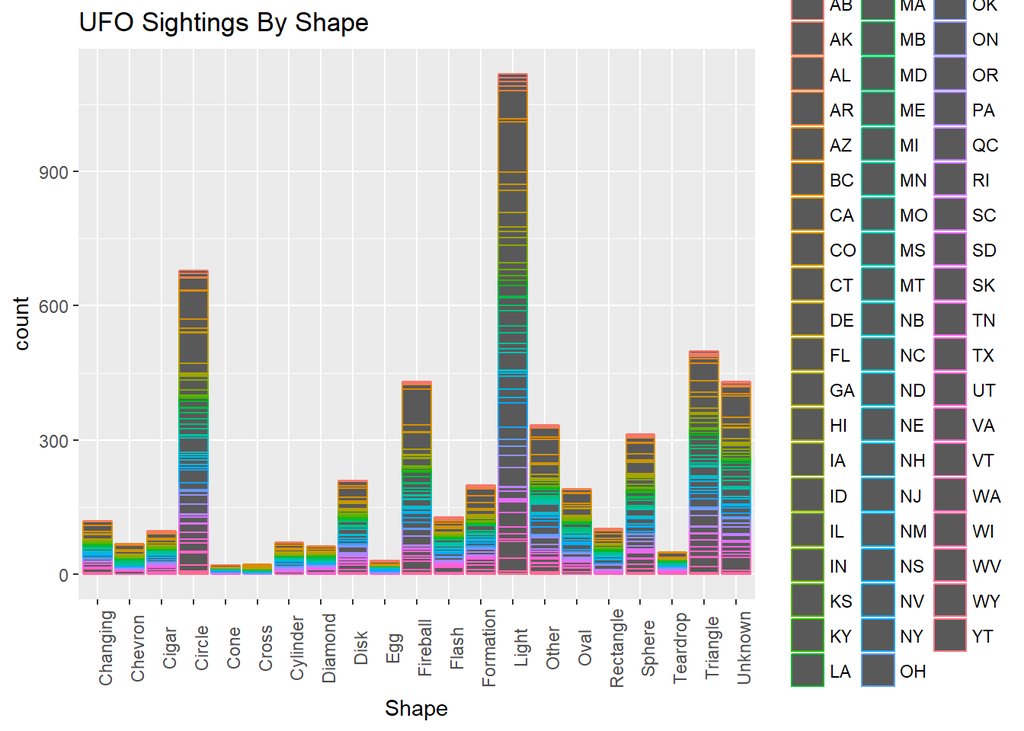

The first graph pictured above represents the data of all UFO *shapes* that were sighted. you can see that there are a variety of shapes that the UFO sightings come in. Most states have a sighting of just about every shape there is. The shape of **Light** seems to appear the most frequently to the UFO spotters. While shapes such as **Cone**, **Cross**, and **Egg** are not quite as common.

# Graph 2: UFO Sightings by State

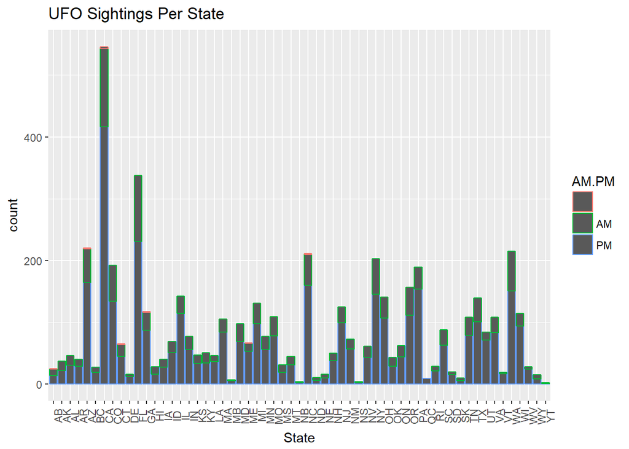